# homework-week-4

Nitin Verma

September 29, 2016

## Homework Problem 1:

Every Saturday, at the same time, a primatologist goes and sits in the forest in the morning and listens for titi monkey calls, counting the number of calls they hear in a 2 hour window from 5am to 7am. Based on previous knowledge, she believes that the mean number calls she will hear in that time is exactly 15. Let X represent the appropriate Poisson random variable of the number of calls heard in each monitoring session. - What is the probability that she will hear more than 8 calls during any given session?

```r
l <- 15
x <- 8

p <- 1 - ppois(q = x, lambda = l)
p
```

```
## [1] 0.9625535
```

- What is the probability that she will hear no calls in a session?

```r
p <- dpois(x = 0, lambda = l)
p
```

```
## [1] 3.059023e-07
```

- What is the probability that she will hear exactly 3 calls in a session?

```r
p <- dpois(x = 3, lambda = l)
p
```

```
## [1] 0.0001720701
```

- Plot the relevant Poisson mass function over the values in range 0 ≤ x ≤ 30.

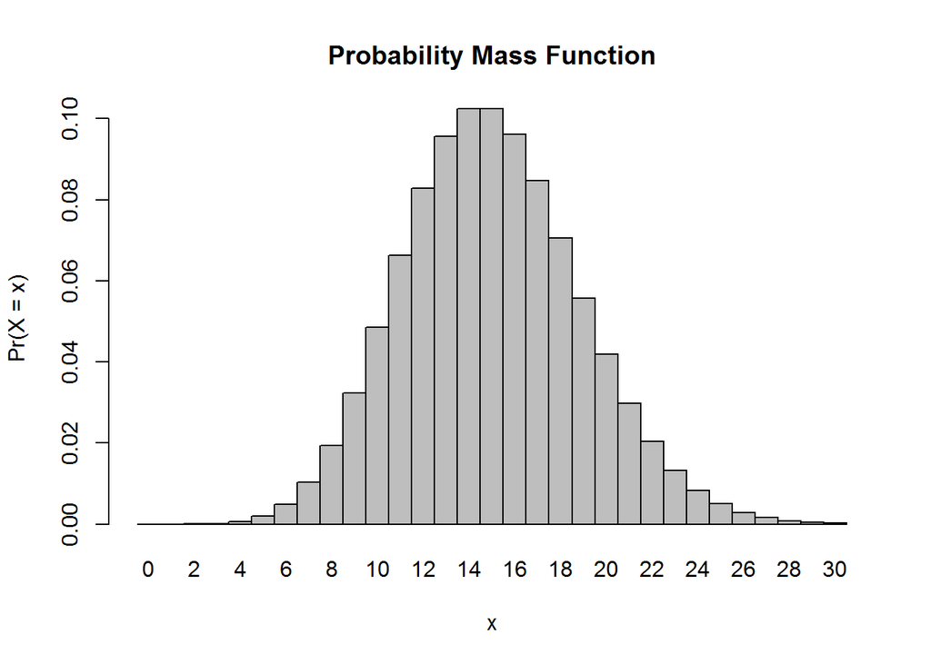

```r
x <- 0:30
l <- 15
probset <- dpois(x = x, lambda = l)
barplot(probset, names.arg = x, space = 0, xlab = "x", ylab = "Pr(X = x)", main = "Probability Mass Function")
```

- Simulate 104 results from this distribution (i.e., 2 years of Saturday monitoring sessions).

```r
x <- rpois(104, lambda = l)
x
```

```
##   [1] 13 16 12 15 11 14 13 18  6  6 11 11 15  8 19 19 12 17 20 12 16 10 16
##  [24]  6 11 20 10 20 20 18 17 21 11 12 15  5 10 12 18 11 15 15 24 18 19 18
##  [47] 12 11  7 24 16 15 12 15 13 12 23  8  9 14 15 12 11 22 15 11 12 14 23
##  [70] 13 10 14 12 16 19 17  9 12 18 13  9 13 17 13 14 16 24 14 14 13 16 10
##  [93] 16 16 12 11 12  9 19 15 11  9 14 13
```

```r
fx <- (l^x * exp(-l))/factorial(x)
fx
```

```
##   [1] 0.095606809 0.096033625 0.082859234 0.102435867 0.066287387
##   [6] 0.102435867 0.095606809 0.070612960 0.004839470 0.004839470
##  [11] 0.066287387 0.066287387 0.102435867 0.019444300 0.055747073
##  [16] 0.055747073 0.082859234 0.084735551 0.041810305 0.082859234
##  [21] 0.096033625 0.048610751 0.096033625 0.004839470 0.066287387
##  [26] 0.041810305 0.048610751 0.041810305 0.041810305 0.070612960
##  [31] 0.084735551 0.029864504 0.066287387 0.082859234 0.102435867
##  [36] 0.001935788 0.048610751 0.082859234 0.070612960 0.066287387
##  [41] 0.102435867 0.102435867 0.008299794 0.070612960 0.055747073
##  [46] 0.070612960 0.082859234 0.066287387 0.010370294 0.008299794
##  [51] 0.096033625 0.102435867 0.082859234 0.102435867 0.095606809
##  [56] 0.082859234 0.013279671 0.019444300 0.032407167 0.102435867
##  [61] 0.102435867 0.082859234 0.066287387 0.020362162 0.102435867
##  [66] 0.066287387 0.082859234 0.102435867 0.013279671 0.095606809
##  [71] 0.048610751 0.102435867 0.082859234 0.096033625 0.055747073
##  [76] 0.084735551 0.032407167 0.082859234 0.070612960 0.095606809
##  [81] 0.032407167 0.095606809 0.084735551 0.095606809 0.102435867
##  [86] 0.096033625 0.008299794 0.102435867 0.102435867 0.095606809
##  [91] 0.096033625 0.048610751 0.096033625 0.096033625 0.082859234
##  [96] 0.066287387 0.082859234 0.032407167 0.055747073 0.102435867
## [101] 0.066287387 0.032407167 0.102435867 0.095606809
```

- Plot the simulated results using hist() and use xlim() to set the horizontal limits to be from 0 to 30. How does your histogram compare to the shape of the probability mass function you plotted above?

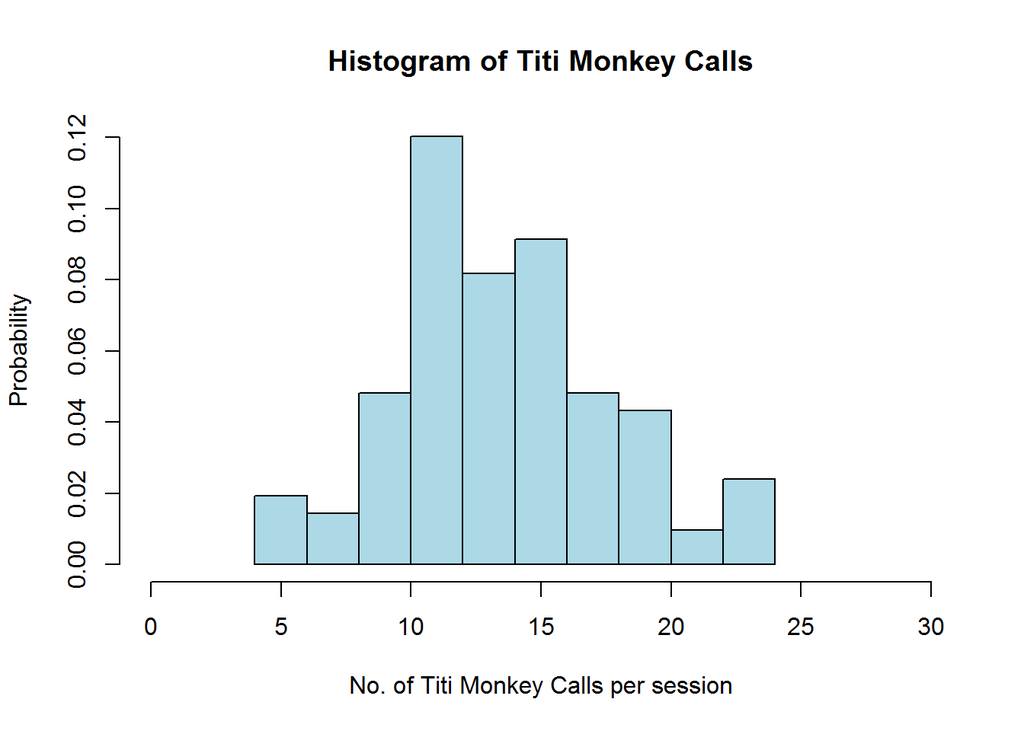

```r
hist(x = x, xlim = c(0,30), freq = FALSE, col = "light blue", xlab = "No. of Titi Monkey Calls per session", ylab = "Probability", main = "Histogram of Titi Monkey Calls")
```